# Статистический анализ рассказов о сновидениях с помощью R

Anastasia Chernaya

12 03 2020

# Статистический анализ рассказов о сновидениях с помощью R: влияет ли диагноз и возраст на длину рассказа.

## Введение

[Здесь](https://github.com/ChernayaAnastasia/Dreaming_corpora_with_R/blob/master/%D0%9C%D0%B5%D1%82%D0%B0%D0%B4%D0%B0%D0%BD%D0%BD%D1%8B%D0%B5%20%D0%BA%D0%BE%D1%80%D0%BF%D1%83%D1%81%D0%B0.md) можно посмотреть детальное описание датасета, в том числе с разными графиками. Мы составили данный датасет на основе текстов корпуса “Рассказы о сновидениях”, взятого с сайта [Проекта «Рассказы о сновидениях и другие корпуса звучащей речи»](http://spokencorpora.ru/showcorpus.py?dir=00dreams). Вкратце: это таблица Excel, в которой 129 рассказов детей и подростков в возрасте от 7 до 17 лет об увиденным ими во сне. 60 рассказов взято от здоровых рассказчиков, 69 - от пациентов с разными невротическими расстройствами. Статистический анализ проводился с помощью языка R с использованием пакетов tidyverse, ez, car, skimr.

## Исследование сырых данных

Итак, загрузим данные:

```
## # A tibble: 3,719 x 5
##       ID Text                     Gender   Age Diagnosis
##    <dbl> <chr>                    <chr>  <dbl> <chr>
##  1     1 Пото                     ж          7 здоров
##  2     1 А потом про зайчика сон. <NA>      NA <NA>
##  3     1 А зайчик вот             <NA>      NA <NA>
##  4     1 он был в лесу.           <NA>      NA <NA>
##  5     1 А я была у речки.        <NA>      NA <NA>
##  6     1 А потом вот я пошла      <NA>      NA <NA>
##  7     1 к домой                  <NA>      NA <NA>
##  8     1 а зайчик за мной         <NA>      NA <NA>
##  9     1 бежал-бежал.             <NA>      NA <NA>
## 10     1 А потом он прибежал      <NA>      NA <NA>
## # … with 3,709 more rows
```

**Посмотрим, как выглядит наш датасет**:

```r
skimr::skim(nds)
```

Data summary

| Name | nds |
| --- | --- |
| Number of rows | 3719 |
| Number of columns | 5 |
| _______________________ |  |
| Column type frequency: |  |
| character | 3 |
| numeric | 2 |
| ________________________ |  |
| Group variables | None |

**Variable type: character**

| skim_variable | n_missing | complete_rate | min | max | empty | n_unique | whitespace |
| --- | --- | --- | --- | --- | --- | --- | --- |
| Text | 0 | 1.00 | 1 | 98 | 0 | 3429 | 0 |
| Gender | 3591 | 0.03 | 1 | 1 | 0 | 2 | 0 |
| Diagnosis | 3591 | 0.03 | 6 | 47 | 0 | 13 | 0 |

**Variable type: numeric**

| skim_variable | n_missing | complete_rate | mean | sd | p0 | p25 | p50 | p75 | p100 | hist |
| --- | --- | --- | --- | --- | --- | --- | --- | --- | --- | --- |
| ID | 0 | 1.00 | 74.97 | 37.56 | 1 | 44 | 80 | 108 | 129 | ▅▃▅▇▇ |
| Age | 3591 | 0.03 | 11.66 | 2.65 | 7 | 10 | 12 | 14 | 17 | ▇▇▆▇▃ |

> Здесь стоит пояснить, что каждая строка текста представляет собой элементраную дискурсивную единицу. (С физиологической точки зрения ЭДЕ произносится на одном выдохе. С синтаксической - каноническая ЭДЕ представляет собой одну предикацию.) Именно количество ЭДЕ у нас будет зависимой переменной.

## Постановка гипотез. Выбор метода анализа.

Нам интересно посмотреть, как влияет возраст и диагноз на: 1) длину рассказа и 2) на разнообразие словаря.

В данной части проекта изучим первый вопрос. И выдвинем такие нулевые гипотезы:

1). Возраст не влияет на длину рассказа

2). Диагноз не влияет на длину рассказа

3). Взаимодействия факторов нет.

Поскольку мы имеем дело с сравнением более двух групп (у нас три возрастные группы), а также нам интересно исследовать влияние сразу нескольких факторов - возраста и диагноза - на длину рассказа (то есть влияние сразу нескольких категориальных предикторных переменных на зависимую переменную), для проверки наших гипотез мы используем **дисперсионный анализ** (ANalysis Of VAriance, ANOVA). В нашем случае это будет двухфакторный дисперсионный анализ (Two-Way ANOVA).

Ниже небольшая справка о дисперсионном анализе:

> Дисперсионный анализ — метод, направленный на поиск зависимостей в экспериментальных данных путём исследования значимости различий в средних значениях. В отличие от t-критерия, позволяет сравнивать средние значения более двух групп. Разработан Р. Фишером для анализа результатов экспериментальных исследований. В литературе также встречается обозначение ANOVA (от англ. ANalysis Of VAriance).

## Подготовка данных для анализа:

**Подставим вместо NA нужные значения с помощью функции fill, создадим дополнительный столбец Health_Group со значениями: здоров и не здоров**.

```r
nds <- nds%>%
  fill(Gender:Diagnosis)

nds <- nds%>%
  mutate(Health_Group = ifelse(Diagnosis == "здоров","здоров", "не здоров"))

nds
```

```
## # A tibble: 3,719 x 6
##       ID Text                     Gender   Age Diagnosis Health_Group
##    <dbl> <chr>                    <chr>  <dbl> <chr>     <chr>
##  1     1 Пото                     ж          7 здоров    здоров
##  2     1 А потом про зайчика сон. ж          7 здоров    здоров
##  3     1 А зайчик вот             ж          7 здоров    здоров
##  4     1 он был в лесу.           ж          7 здоров    здоров
##  5     1 А я была у речки.        ж          7 здоров    здоров
##  6     1 А потом вот я пошла      ж          7 здоров    здоров
##  7     1 к домой                  ж          7 здоров    здоров
##  8     1 а зайчик за мной         ж          7 здоров    здоров
##  9     1 бежал-бежал.             ж          7 здоров    здоров
## 10     1 А потом он прибежал      ж          7 здоров    здоров
## # … with 3,709 more rows
```

**Разобьем детей по возрастным группам следующим образом**:

1). 7 -11 лет - младшие дети (juniors),

2). 12-14 лет - старшие дети (young teens),

3). 15 -17 лет - подростки (teens).

**Далее мы отфильтруем ровно те данные, которые нам понадобятся для иследования**.

Мы создадим выборку по возрастным группам для больных и здоровых и посчитаем ЭДЕ по каждому рассказу.

```r
nds <- nds%>%
 mutate(Age_Group = ifelse(Age %in% 7:11, 'juniors',
        ifelse(Age %in% 12:14, 'young teens',
        ifelse(Age %in% 15:17, 'teens', NA))))

ag_h <- nds%>%
  group_by(Age_Group, ID)%>%
  count(Health_Group,ID)%>%
  group_by(Health_Group)

skimr::skim(ag_h)
```

Data summary

| Name | ag_h |
| --- | --- |
| Number of rows | 129 |
| Number of columns | 4 |
| _______________________ |  |
| Column type frequency: |  |
| character | 1 |
| numeric | 2 |
| ________________________ |  |
| Group variables | Health_Group |

**Variable type: character**

| skim_variable | Health_Group | n_missing | complete_rate | min | max | empty | n_unique | whitespace |
| --- | --- | --- | --- | --- | --- | --- | --- | --- |
| Age_Group | здоров | 0 | 1 | 5 | 11 | 0 | 3 | 0 |
| Age_Group | не здоров | 0 | 1 | 5 | 11 | 0 | 3 | 0 |

**Variable type: numeric**

| skim_variable | Health_Group | n_missing | complete_rate | mean | sd | p0 | p25 | p50 | p75 | p100 | hist |
| --- | --- | --- | --- | --- | --- | --- | --- | --- | --- | --- | --- |
| ID | здоров | 0 | 1 | 30.50 | 17.46 | 1 | 15.75 | 30.5 | 45.25 | 60 | ▇▇▇▇▇ |
| ID | не здоров | 0 | 1 | 95.00 | 20.06 | 61 | 78.00 | 95.0 | 112.00 | 129 | ▇▇▇▇▇ |
| n | здоров | 0 | 1 | 21.75 | 10.95 | 6 | 13.75 | 19.5 | 30.00 | 52 | ▇▇▅▃▁ |
| n | не здоров | 0 | 1 | 34.99 | 31.72 | 9 | 17.00 | 26.0 | 39.00 | 195 | ▇▂▁▁▁ |

## Разведочный анализ отфильтрованных данных

**Посмотрим на объем выборки**

Мы подсчитаем, сколько больных и здоровых в каждой возрастной выборке и визуализируем данные.

```r
count <- ag_h%>%
  group_by(Age_Group)%>%
  count(Health_Group)
```

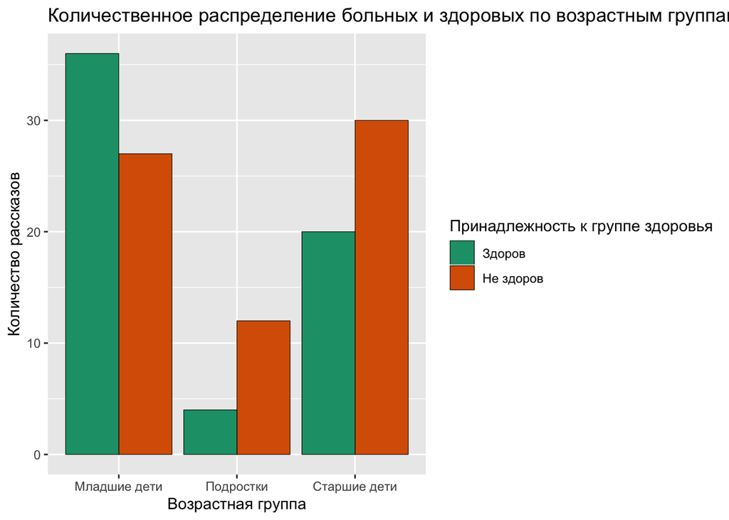

```r
ggplot(data = count, mapping = aes(x = Age_Group, y = n, fill = Health_Group)) +
  geom_col(color = 'black', size = 0.2, position = 'dodge')+
  ggtitle('Количественное распределение больных и здоровых по возрастным группам') +
  labs(x = 'Возрастная группа', y = 'Количество рассказов')+
  scale_x_discrete (labels = c("Младшие дети", "Подростки", "Старшие дети"))+
  scale_fill_brewer(name = 'Принадлежность к группе здоровья', palette = "Dark2",
                    labels = c('Здоров', 'Не здоров'))
```

Мы видим, что у нас *несбалансированные данные* (разное количество наблюдений в каждой группе). Особенно выбивается группа teens.

**Посмотрим, как выглядят наши данные**

Построим график средних и их доверительных интервалов. Если объединить точки одного цвета линиями, то эти линии не будут пересекаться. Это нам показывает, что в данном двухфакторном анализе не будет взаимодействие факторов (позже мы это проверим).

```
## No summary function supplied, defaulting to `mean_se()
```

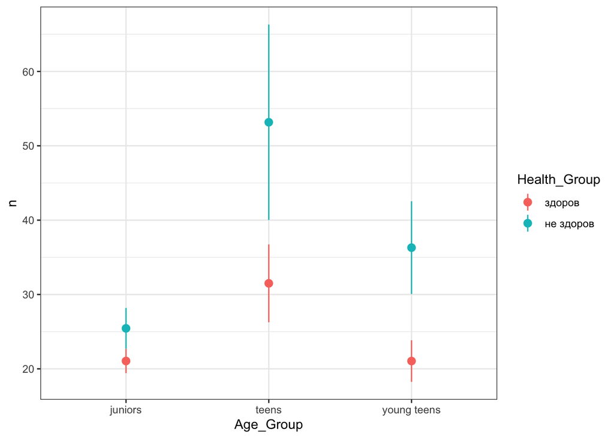

```r
theme_set(theme_bw())
ggplot(ag_h, aes(x = Age_Group, y = n, color = Health_Group))+
  stat_summary()
```

Итак, у нас есть *одна зависимая переменная*: **количество ЭДЕ (n)** и *два дискретных фактора*:**здоров или не здоров (Health_Group), возрастная группа (Age_Group)**. Наши факторы кодируются разными значениями.

## Создание модели для тестирования

Построим **линейную модель в параметризации индикаторных переменных** с помощью функции линейной регрессии lm (). Эту модель мы будем использовать для проверки условий применимости дисперсионного анализа:

```r
mod_as_lm <- lm(n ~ Health_Group * Age_Group, data = ag_h)
summary(mod_as_lm)
```

```
##
## Call:
## lm(formula = n ~ Health_Group * Age_Group, data = ag_h)
##
## Residuals:
##     Min      1Q  Median      3Q     Max
## -44.167 -12.050  -3.300   5.944 158.700
##
## Coefficients:
##                                             Estimate Std. Error t value
## (Intercept)                                21.055556   3.936386   5.349
## Health_Groupне здоров                       4.388889   6.012930   0.730
## Age_Groupteens                             10.444444  12.447947   0.839
## Age_Groupyoung teens                       -0.005556   6.586834  -0.001
## Health_Groupне здоров:Age_Groupteens       17.277778  14.902919   1.159
## Health_Groupне здоров:Age_Groupyoung teens 10.861111   9.090695   1.195
##                                            Pr(>|t|)
## (Intercept)                                4.15e-07 ***
## Health_Groupне здоров                         0.467
## Age_Groupteens                                0.403
## Age_Groupyoung teens                          0.999
## Health_Groupне здоров:Age_Groupteens          0.249
## Health_Groupне здоров:Age_Groupyoung teens    0.234
## ---
## Signif. codes:  0 '***' 0.001 '**' 0.01 '*' 0.05 '.' 0.1 ' ' 1
##
## Residual standard error: 23.62 on 123 degrees of freedom
## Multiple R-squared:  0.1542, Adjusted R-squared:  0.1198
## F-statistic: 4.484 on 5 and 123 DF,  p-value: 0.0008681
```

При помощи функции fortify из пакета ggplot создадим *модель с необходимой диагностической информацией*:

```r
mod_as_lm_diag <- fortify(mod_as_lm)
head(mod_as_lm_diag)
```

```
##    n Health_Group Age_Group       .hat   .sigma      .cooksd  .fitted
## 1 46       здоров   juniors 0.02777778 23.60405 5.463424e-03 21.05556
## 2 22       здоров   juniors 0.02777778 23.71476 7.831952e-06 21.05556
## 3 18       здоров   juniors 0.02777778 23.71326 8.197805e-05 21.05556
## 4  6       здоров   juniors 0.02777778 23.67459 1.990264e-03 21.05556
## 5  6       здоров   juniors 0.02777778 23.67459 1.990264e-03 21.05556
## 6 14       здоров   juniors 0.02777778 23.70607 4.370988e-04 21.05556
##        .resid   .stdresid
## 1  24.9444444  1.07112976
## 2   0.9444444  0.04055502
## 3  -3.0555556 -0.13120743
## 4 -15.0555556 -0.64649480
## 5 -15.0555556 -0.64649480
## 6  -7.0555556 -0.30296989
```

> .hat — “сила воздействия” данного наблюдения (leverage)

> .cooksd — расстояние Кука

> .fitted — предсказанные значения

> .resid — остатки

> .stdresid — стандартизованные остатки

Проверим **наличие влиятельных наблюдений** в модели. Для этого мы построим график расстояния Кука:

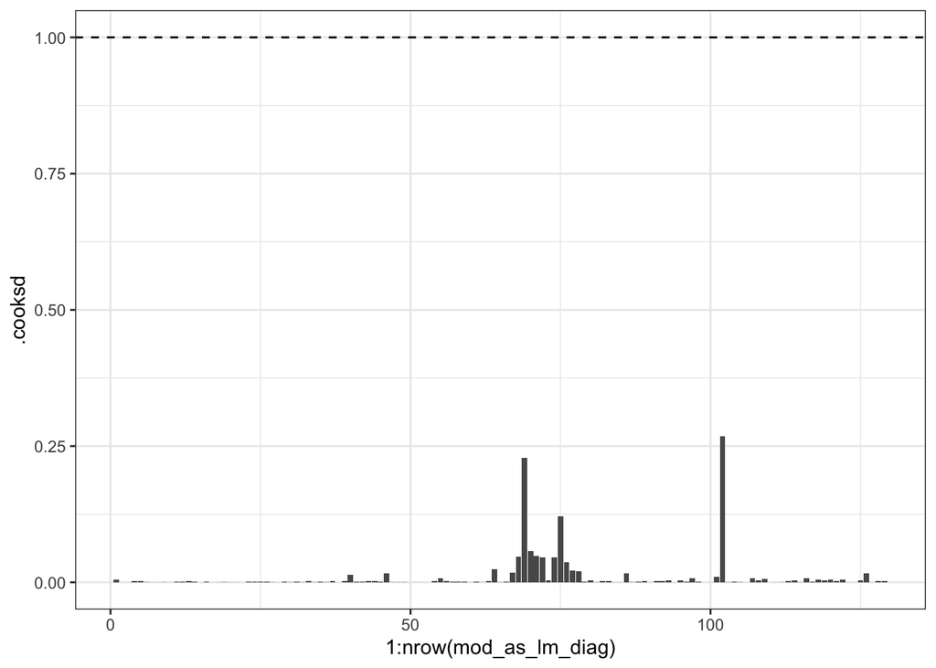

```r
ggplot(mod_as_lm_diag, aes(x = 1:nrow(mod_as_lm_diag), y = .cooksd))+
  geom_bar(stat = 'identity')+
  geom_hline(yintercept = 1, linetype = 2)
```

Если сравнивать расстояние Кука с мягким пороговым значением 1, то мы видим, что *влиятельных наблюдений нет.*

Одно из важных условий применимости - **равенство дисперсий (или гомогенность дисперсий)**.

Проведем тест Ливиня (Levene’s Test) из пакета car для проверки равенства дисперсий.

```r
library(car)
leveneTest(n ~ Health_Group * Age_Group, ag_h)
```

```
## Levene's Test for Homogeneity of Variance (center = median)
##        Df F value  Pr(>F)
## group   5  5.7163 8.9e-05 ***
##       123
## ---
## Signif. codes:  0 '***' 0.001 '**' 0.01 '*' 0.05 '.' 0.1 ' ' 1
```

Для наглядности можно также построить боксплот:

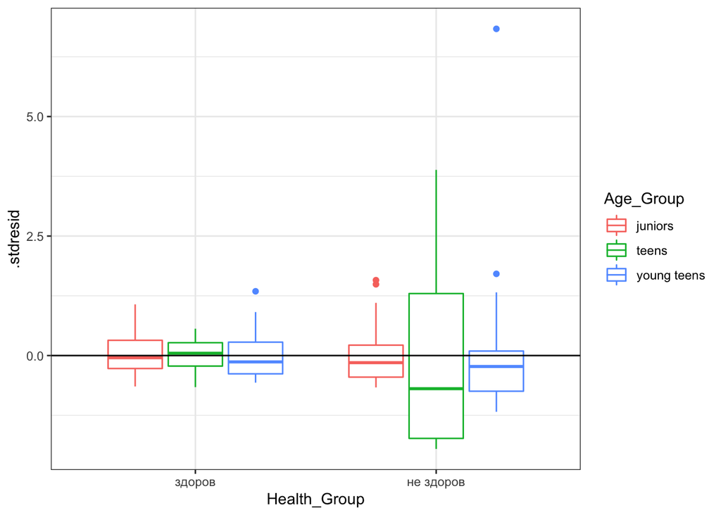

```r
ggplot(data = mod_as_lm, aes (x = Health_Group, y = .stdresid, color = Age_Group))+
  geom_boxplot()+geom_hline(yintercept = 0)
```

Мы видим, что у нас есть *явный разброс дисперсии в группе teens*. Это конечно подозрительно.

Посмотрим также на **распределение нашей зависимой переменной**:

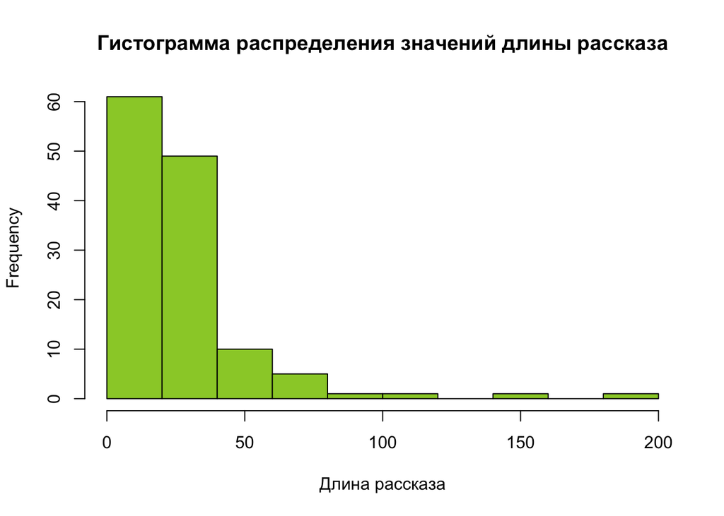

```r
hist(ag_h$n, main = "Гистограмма распределения значений длины рассказа",
     xlab = "Длина рассказа", col = "olivedrab3")
```

Мы видим, что распределение не является нормальным.

Последний диагностический тест: **нормально ли распределены стьюдентизированные остатки**.

Для этого построим квантильный график стьюдентизированных остатков.

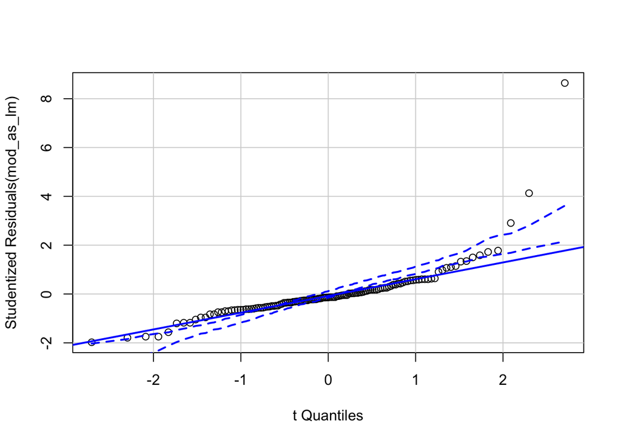

```r
qq_Plot <- qqPlot(mod_as_lm, id = FALSE)
```

## Дисперсионный анализ: интерпретация результатов.

Поскольку у нас несбалансированные данные, то проведем дисперсионный анализ со вторым типом суммы квадратов.

Это можно сделать с помощью функции Anova() из пакета car, прописав type = II.

```r
Anova(mod_as_lm, type = "II")
```

```
## Anova Table (Type II tests)
##
## Response: n
##                        Sum Sq  Df F value   Pr(>F)
## Health_Group             3276   1  5.8723 0.016837 *
## Age_Group                5663   2  5.0762 0.007616 **
## Health_Group:Age_Group   1221   2  1.0940 0.338101
## Residuals               68612 123
## ---
## Signif. codes:  0 '***' 0.001 '**' 0.01 '*' 0.05 '.' 0.1 ' ' 1
```

Функция ezANOVA() из пакета ez не требует специальной модели - объекта lm и она по умолчанию считает со вторым типом суммы квадратов:

```r
 library(ez)
ezANOVA(data = ag_h,
        dv = n,
        wid = ID,
        between = .(Health_Group, Age_Group))
```

```
## Coefficient covariances computed by hccm()
```

```
## $ANOVA
##                   Effect DFn DFd        F           p p<.05        ges
## 1           Health_Group   1 123 5.872310 0.016837265     * 0.04556688
## 2              Age_Group   2 123 5.076154 0.007615871     * 0.07624582
## 3 Health_Group:Age_Group   2 123 1.094028 0.338100707       0.01747816
##
## $`Levene's Test for Homogeneity of Variance`
##   DFn DFd      SSn      SSd       F            p p<.05
## 1   5 123 9232.737 39733.14 5.71627 8.900246e-05     *
```

Поскольку у нас нарушаются два важных условиях (гомгенность дисперсии и нормальность распределения), логарифмируем нашу модель и проведем снова дисперсионный анализ.

#### Логарифмирование модели

**ezANOVA с логарифмированием**

```r
 library(ez)
ezANOVA(data = ag_h,
        dv = LogN,
        wid = ID,
        between = .(Health_Group, Age_Group))
```

```
## Coefficient covariances computed by hccm()
```

```
## $ANOVA
##                   Effect DFn DFd         F          p p<.05        ges
## 1           Health_Group   1 123 6.8244935 0.01011193     * 0.05256707
## 2              Age_Group   2 123 3.0837381 0.04934512     * 0.04774790
## 3 Health_Group:Age_Group   2 123 0.7361707 0.48104258       0.01182866
##
## $`Levene's Test for Homogeneity of Variance`
##   DFn DFd      SSn      SSd        F          p p<.05
## 1   5 123 2.263329 15.37654 3.620962 0.00432704     *
```

##### Проинтерпретируем результаты дисперсионного анализа:

Оба теста дают одинаковые результаты: p-Value < 0.05 и для фактора Health_Group, и для Age_Group, то есть мы можем отвергнуть первые две нулевые гипотезы и заключить, что **и возраст, и диагноз влияют на длину рассказов**. При этом гипотезу об отсутствии взаимодействия факторов мы не можем отвергнуть. Покажем результаты наглядно на графике.

## Визуализация результатов

Создадим искуственный датафрейм, который будет содержать все значения предикторов с помощью expand.grid()

```r
data_for_viz <- expand.grid(Health_Group = levels(ag_h$Health_Group),
                            Age_Group = levels(ag_h$Age_Group))
```

Собираем данные для графика вручную :

```r
X <- model.matrix(~Health_Group * Age_Group, data = data_for_viz) #Модельная матрица
betas <- coef(mod_as_lm) #Коэффициенты
data_for_viz$fit <- X%*% betas #Предсказанные значения
data_for_viz$se <- sqrt(diag(X %*% vcov(mod_as_lm)%*% t(X))) #Стандартные ошибки
t_crit <- qt(0.975, df = nrow(ag_h) - length(coef(mod_as_lm)))# t для доверит интервала
data_for_viz$lwr <- data_for_viz$fit - t_crit * data_for_viz$se
data_for_viz$upr <- data_for_viz$fit + t_crit * data_for_viz$se
```

Черновой график результатов:

```r
gg_linep <- ggplot(data = data_for_viz, aes(x = Age_Group, y = fit,
              ymin = lwr, ymax = upr, color= Health_Group))+
  geom_point()+
  geom_line(aes(group = Health_Group))+
  geom_errorbar(width = 0.1)
```

Улучшенный график (сдвигаем графики друг относительно друга, чтобы линии не накладывались):

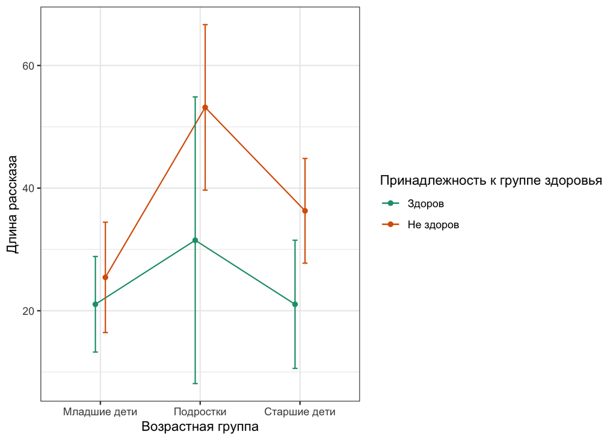

```r
pos <- position_dodge(width = 0.2)
gg_linep <- ggplot(data = data_for_viz, aes(x = Age_Group, y = fit,
                                            ymin = lwr, ymax = upr, color = Health_Group))+
  geom_point(position = pos)+
  geom_line(aes(group = Health_Group), position = pos)+
  geom_errorbar(width = 0.1, position=pos)

gg_final <- gg_linep + labs(x = 'Возрастная группа', y = 'Длина рассказа') +
  scale_x_discrete(labels = c("Младшие дети", "Подростки", "Старшие дети"))+
  scale_color_brewer(name = 'Принадлежность к группе здоровья', palette = "Dark2",
      labels = c('Здоров', 'Не здоров'))

gg_final
```

На графике хорошо видно, что дети с диагнозом во всех возрастных группах порождают более длинные рассказы. При этом факторы не взаимодействуют (наши линии не пересекаются).